# Quantile GAM modelling with qgam and mgcViz

Matteo Fasiolo

June 10 2025

The `qgam` R package offers methods for fitting additive quantile regression models based on splines. It is useful to use `qgam` together with `mgcViz`, which extends the basic visualizations provided by `mgcv`.

The main fitting functions are:

- `qgam()` fits an additive quantile regression model to a single quantile. Very similar to `mgcv::gam()`. It returns an object of class `qgam`.
- `mqgam()` fits the same additive quantile regression model to several quantiles. It is more efficient that calling `qgam()` several times, especially in terms of memory usage.
- `qgamV()` and `mqgamV()` are two convenient wrappers that fit quantile GAMs and return `gamViz` objects, for which `mgcViz` provides lots of visualizations.

# Quantile modelling: the motorcycle data set

Let us consider the motorcycle data set:

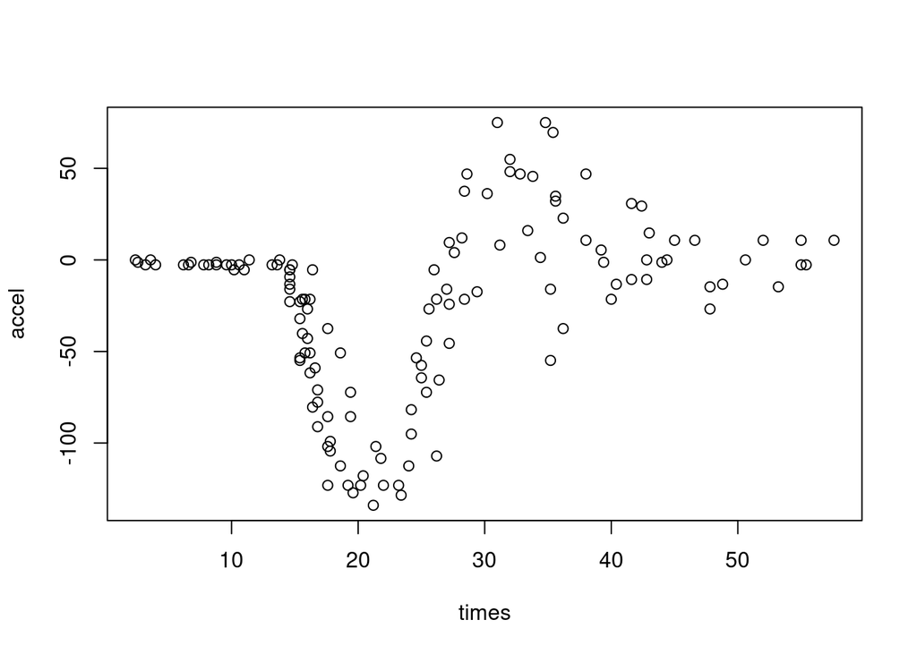

```r
library(MASS)
data(mcycle)
plot(mcycle)
```

We fit a quantile GAM for quantile 0.9

```r
library(qgam)
library(mgcViz)
fit09 <- qgam(accel ~ s(times, k=20, bs="ad"),
              data = mcycle,
              qu = 0.9)
```

```
## Estimating learning rate. Each dot corresponds to a loss evaluation.
## qu = 0.9.....................done
```

We now plot the quantile with confidence intervals

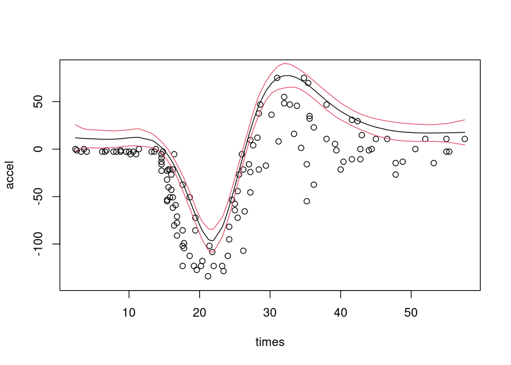

```r
pred <- predict(fit09, se = TRUE)

plot(mcycle, ylim = c(-140, 85))
lines(mcycle$times, pred$fit)
lines(mcycle$times, pred$fit + 2 * pred$se, col = 2)
lines(mcycle$times, pred$fit - 2 * pred$se, col = 2)
```

There are two problems with this fit:

- the confidence intervals have nearly constant width;
- the estimated quantile is far above the data for `times < 15`.

We address these issues by modelling the learning rate as well

```r
fit09_2 <- qgam(list(accel ~ s(times, k=20, bs="ad"),
                           ~ s(times)),
                 data = mcycle,
                 qu = 0.9)
```

```
## Estimating learning rate. Each dot corresponds to a loss evaluation.
## qu = 0.9.....................done
```

Again predict and plot

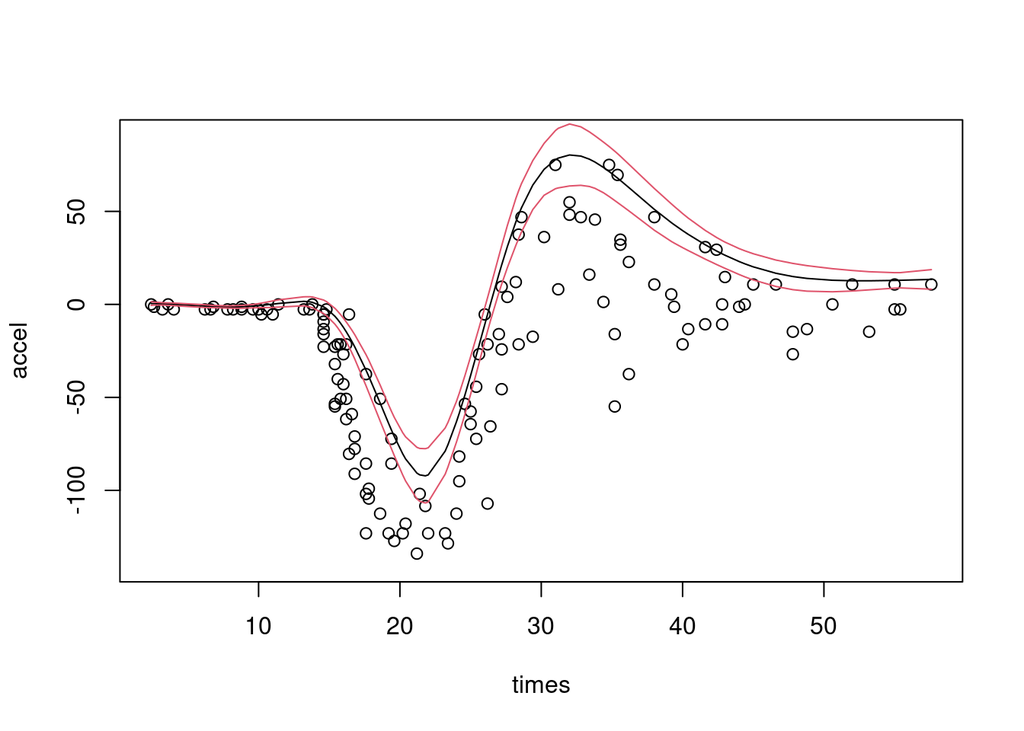

```r
pred <- predict(fit09_2, se = TRUE)

plot(mcycle, ylim = c(-140, 90))
lines(mcycle$times, pred$fit)
lines(mcycle$times, pred$fit + 2 * pred$se, col = 2)
lines(mcycle$times, pred$fit - 2 * pred$se, col = 2)
```

Looks much better! Recall that

```r
class(fit09_2)
```

```
## [1] "qgam" "gam"  "glm"  "lm"
```

hence we can do, for instance

```r
summary(fit09_2)
```

```
##
## Family: elf
## Link function: identity
##
## Formula:
## accel ~ s(times, k = 20, bs = "ad")
##
## Parametric coefficients:
##             Estimate Std. Error z value Pr(>|z|)
## (Intercept)    2.305      1.508   1.529    0.126
##
## Approximate significance of smooth terms:
##            edf Ref.df Chi.sq p-value
## s(times) 11.58  13.17  548.4  <2e-16 ***
## ---
## Signif. codes:  0 '***' 0.001 '**' 0.01 '*' 0.05 '.' 0.1 ' ' 1
##
## R-sq.(adj) =  0.673   Deviance explained = 97.3%
## -REML = 573.57  Scale est. = 1         n = 133
```

We can use `mgcViz` plots by converting as usual

```r
fit09_2 <- getViz(fit09_2, nsim = 100) # Note nsim does not make sense here!
```

or using shortcut

```r
fit09_2 <- qgamV(list(accel ~ s(times, k=20, bs="ad"),
                            ~ s(times)),
                 data = mcycle,
                 qu = 0.9)
```

We fit multiple quantiles using the `mqgam` function

```r
fitMQ <- mqgam(list(accel ~ s(times, k=20, bs="ad"),
                            ~ s(times)),
               data = mcycle,
               qu = c(0.1, 0.25, 0.5, 0.75, 0.9))
```

```
## Estimating learning rate. Each dot corresponds to a loss evaluation.
## qu = 0.5.........................done
## qu = 0.25............done
## qu = 0.75............done
## qu = 0.1.................done
## qu = 0.9..........done
```

This should be manipulated using the `qdo` function

```r
qdo(fitMQ, 0.1, summary)
```

```
##
## Family: elf
## Link function: identity
##
## Formula:
## accel ~ s(times, k = 20, bs = "ad")
##
## Parametric coefficients:
##             Estimate Std. Error z value Pr(>|z|)
## (Intercept)  -54.736      2.076  -26.37   <2e-16 ***
## ---
## Signif. codes:  0 '***' 0.001 '**' 0.01 '*' 0.05 '.' 0.1 ' ' 1
##
## Approximate significance of smooth terms:
##            edf Ref.df Chi.sq p-value
## s(times) 8.655   9.43   1184  <2e-16 ***
## ---
## Signif. codes:  0 '***' 0.001 '**' 0.01 '*' 0.05 '.' 0.1 ' ' 1
##
## R-sq.(adj) =  0.645   Deviance explained = 90.2%
## -REML = 584.94  Scale est. = 1         n = 133
```

To plot one of the fitted quantile models we do

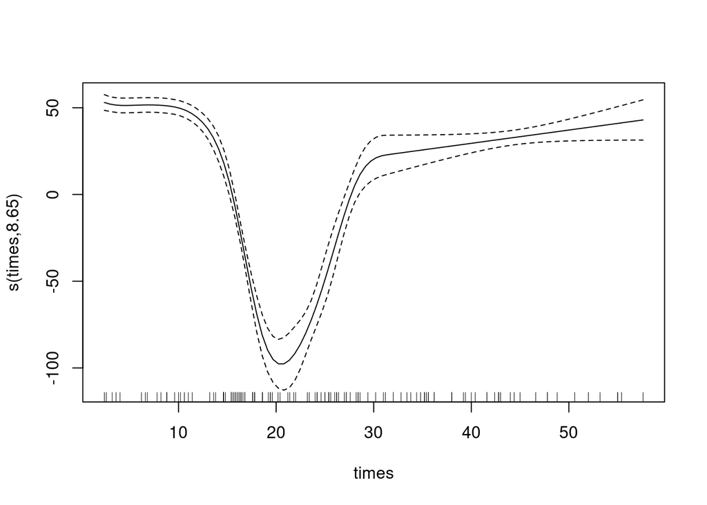

```r
qdo(fitMQ, 0.1, plot)
```

To plot effect of several quantile at once we use `mgcViz`

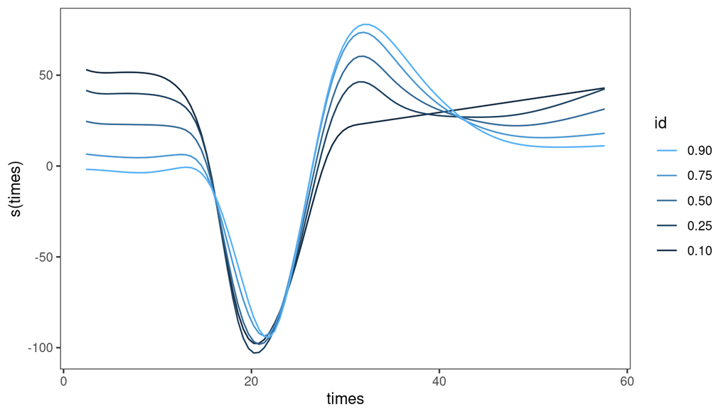

```r
fitMQ_viz <- getViz(fitMQ)

plot(fitMQ_viz)
```

We can plot the fitted quantile on the data

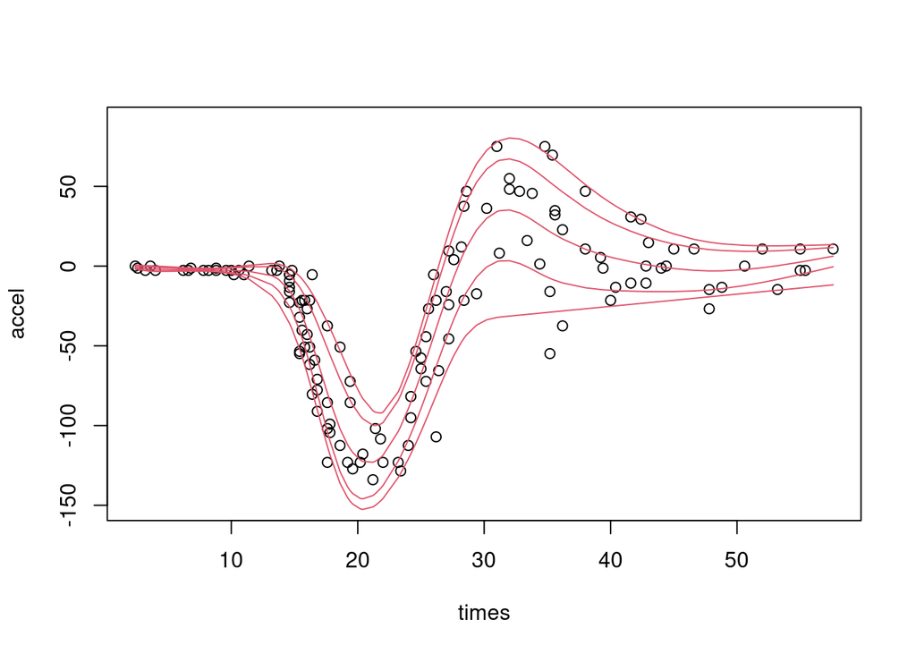

```r
plot(mcycle, ylim = c(-150, 90))
for(ii in 1:5) lines(mcycle$times, predict(fitMQ_viz[[ii]]), col = 2)
```

NB output of `getViz` is simply a list of `gam` models, we don’t need to use `qdo`. But there is a memory price to pay (small for this small data set)

```r
format(object.size(fitMQ), units = "MB")
```

```
## [1] "1.4 Mb"
```

```r
format(object.size(fitMQ_viz), units = "MB")
```

```
## [1] "1.5 Mb"
```

To recap we can do

- `fit <- qgam(...)` and then `fit <- getViz(fit)`, or `fit <- qgamV(...)` directly
- `fit <- mqgam(...)` and we use `qdo(fit, 0.1, plot)`
- `fit <- mqgam(...)`, then `fit <- getViz(fit)` and finally `plot(fit[[1]])`
- `fit <- mqgamV(...)` and `plot(fit)` or `plot(fit[[1]])`

# Big Data QGAM modelling of rainfall in Parana state of Brasil

Here we are going to model weekly rainfall (mm/week) from over 600 weather station in the Parana state of Brazil. The data comes comes from the `INLA` R package. The meaning of most variables should be evident.

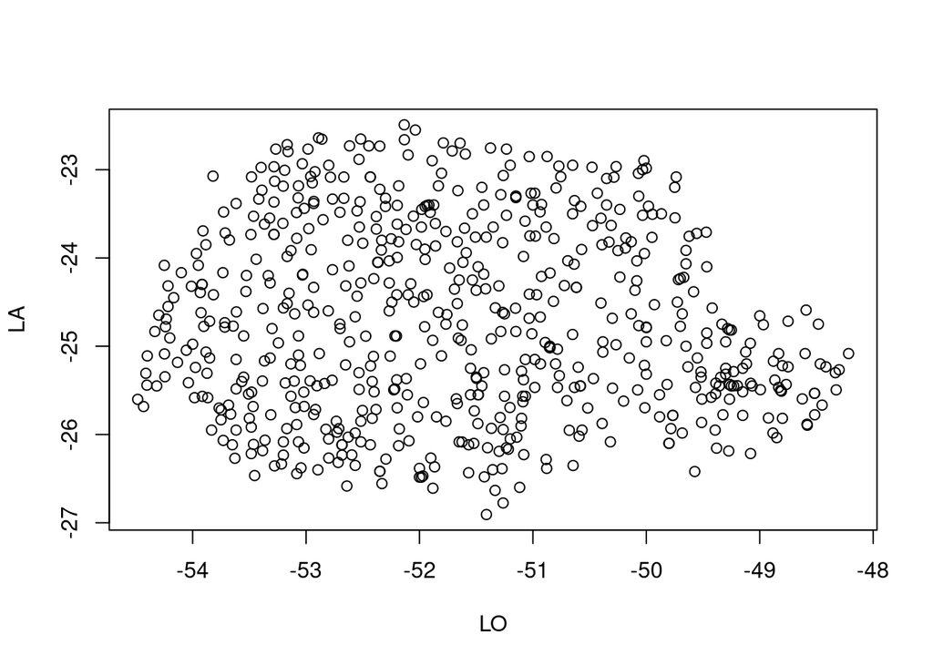

```r
library(testGam)
data("parana")

plot(parana[parana$TIME==1, ]$LO, parana[parana$TIME==1, ]$LA, xlab = "LO", ylab = "LA")
```

We fit a quantile GAM for $\tau = 0.8$ with an isotropic effect for longitude and latitude, a cyclic effect for the time of the year and smooth effects for distance from the sea and elevation:

```r
library(mgcViz)
fit <- qgamV(PREC ~ s(LO, LA, k = 25) + s(seaDist) + s(TIME, bs = "cc") + s(EL),
             aQgam = list(discrete = TRUE),
             data = parana,
             qu = 0.8)
```

```
## Estimating learning rate. Each dot corresponds to a loss evaluation.
## qu = 0.8..........done
```

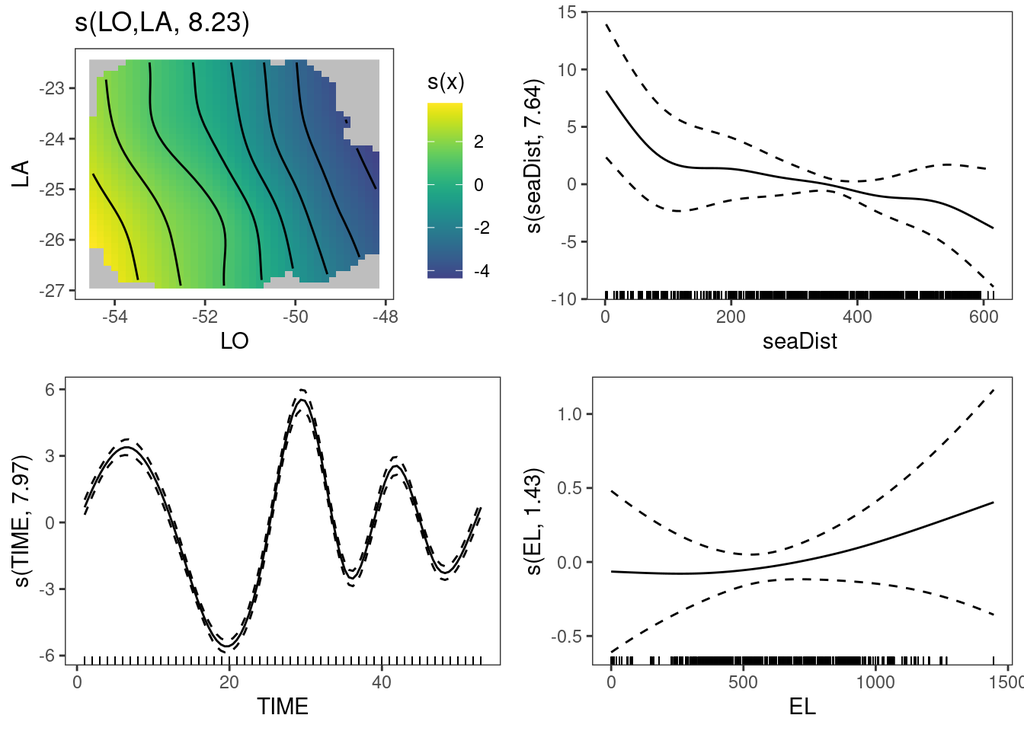

```r
print(plot(fit), pages = 1)
```

Hence we can do model checking in `mgcViz`. However standard tools are inadequate

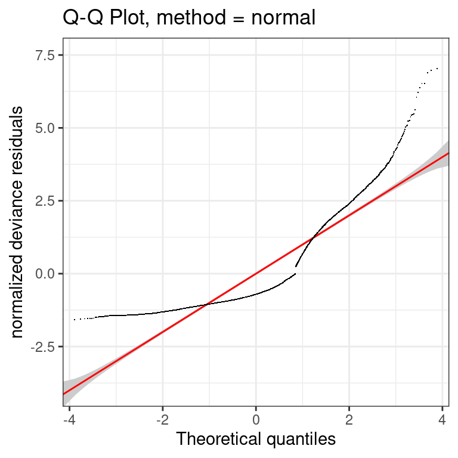

```r
qq(fit, CI = "normal")
```

But we can verify number of observations falling below the fit

```r
mean( (parana$PREC - fit$fitted.values) < 0 )
```

```
## [1] 0.8026776
```

and `mgcViz` provides a specific layer for doing this along one covariate

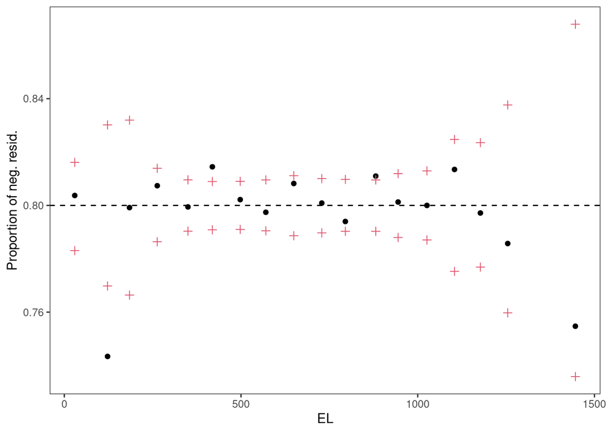

```r
check1D(fit, x = "EL") + l_gridQCheck1D()
```

or two covariates

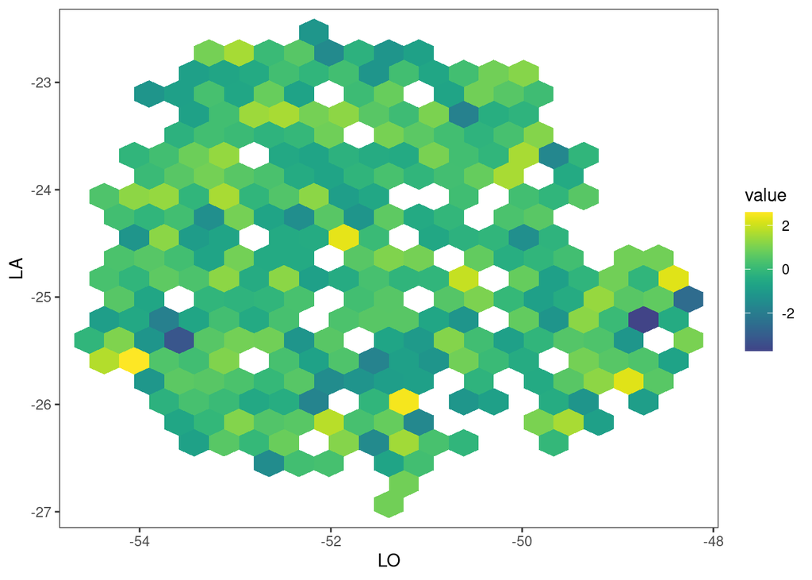

```r
check2D(fit, x1 = "LO", x2 = "LA") + l_gridQCheck2D()
```

We can of course fit this model to several quantiles (this takes several seconds):

```r
fitM <- mqgamV(PREC ~ s(LO, LA, k = 25) + s(seaDist) + s(TIME, bs = "cc") + s(EL),
               aQgam = list(discrete = TRUE),
               data = parana,
               qu = seq(0.1, 0.9, length.out = 5))
```

```
## Estimating learning rate. Each dot corresponds to a loss evaluation.
## qu = 0.5......done
## qu = 0.3....................done
## qu = 0.7.........done
## qu = 0.1.................done
## qu = 0.9........done
```

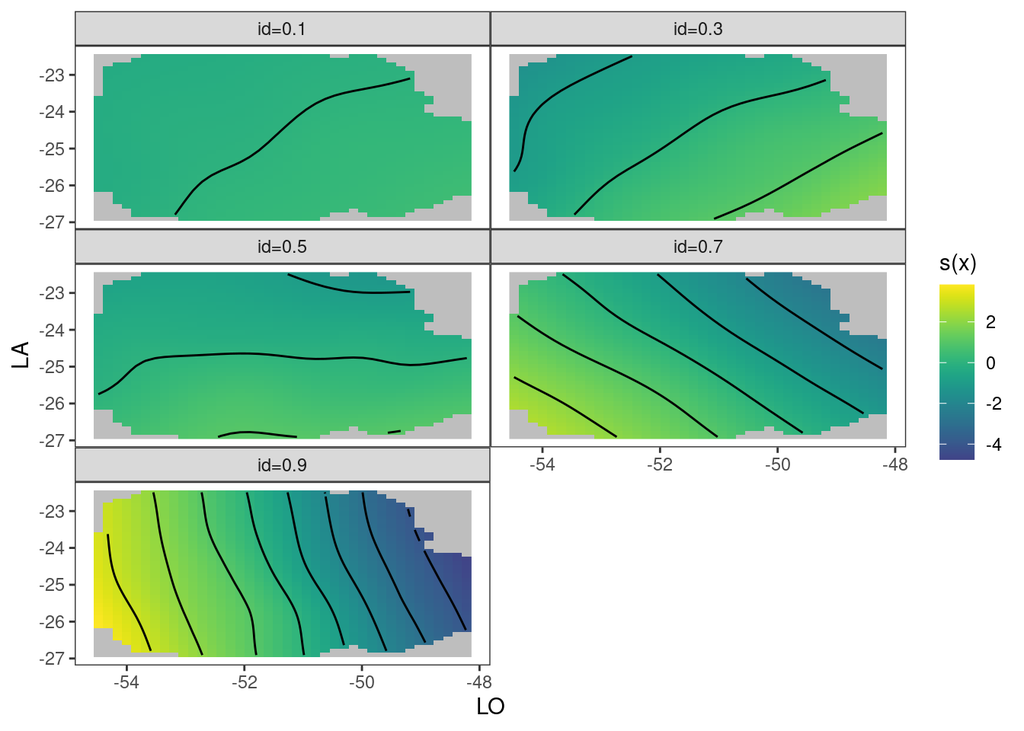

```r
plot(fitM, select = 1)
```

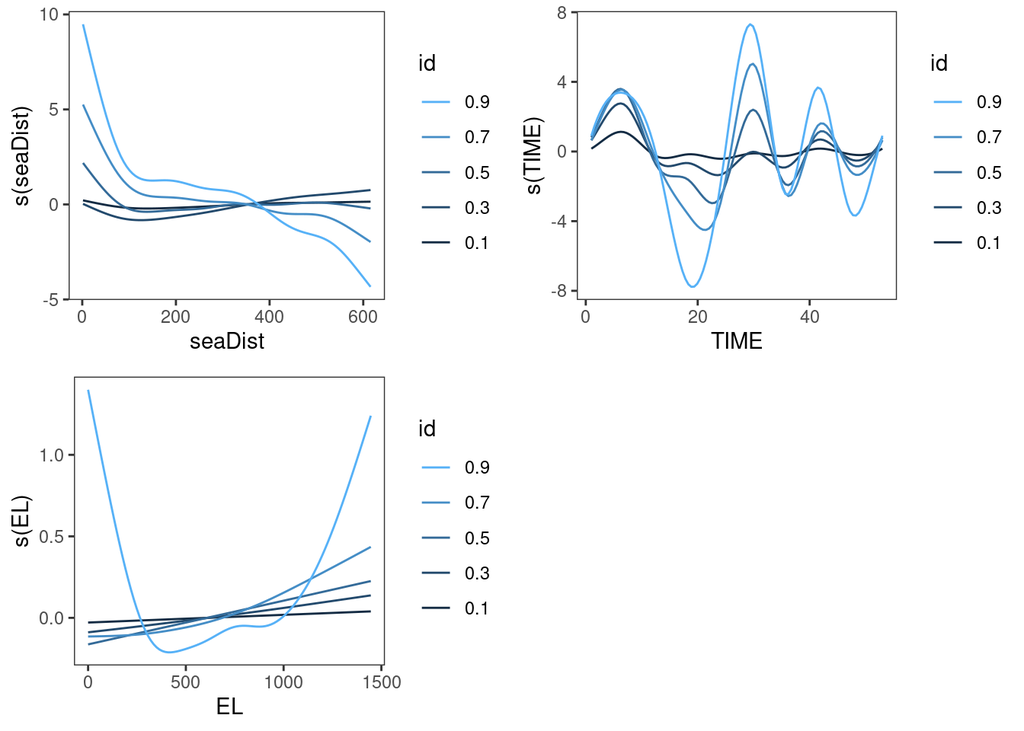

```r
print(plot(fitM, select = 2:4), pages = 1)
```

Notice that the spatial effect seems much stronger for high quantiles than for the low ones. The same is true for distance from the sea and seasonality (`TIME`), while the effect of elevation is not significant from `qu = 0.9`. We can visualize the spatial effect in 3D as follows:

```r
plotRGL(sm(fitM[[5]], 1))
```

[interactive chart not shown]

We might also wonder whether the spatial effect changes with time. To verify this here we construct a tensor product smooth between the 2D thin-plate-spline spatial effect and the cyclical effect of time. We simplify the model by removing the effect of `seaDist` (this takes several minutes!):

```r
fit4 <- qgamV(PREC ~ te(LO, LA, TIME, d = c(2, 1), k = c(20, 10), bs = c("tp", "cc")) + s(EL),
              aQgam = list(discrete = TRUE),
              data = parana,
              qu = 0.9)
```

```
## Estimating learning rate. Each dot corresponds to a loss evaluation.
## qu = 0.9........done
```

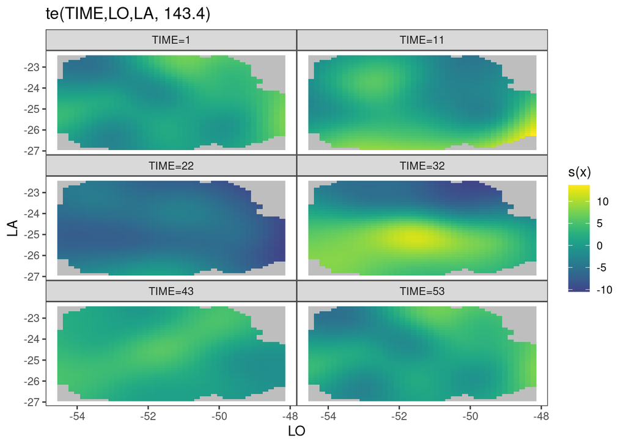

```r
plotSlice(sm(fit4, 1),
          fix = list("TIME" = round(seq(1, 53, length.out = 6)))) + l_fitRaster()
```

You can plot any slice in 3D by doing:

```r
plotRGL(sm(fit4, 1), fix = c("TIME" = 11))
```

[interactive chart not shown]